# Задача о погоне

Герра Гарсия Паола Валентина

Российский Университет Дружбы Народов

7 марта 2025, Москва, Россия

# Цели и задачи работы

## Цель лабораторной работы

На море в тумане катер береговой охраны преследует лодку браконьеров. Через определенный промежуток времени туман рассеивается, и лодка обнаруживается на расстоянии k км от катера. Затем лодка снова скрывается в тумане и уходит прямолинейно в неизвестном направлении. Известно, что скорость катера в n раза больше скорости браконьерской лодки. Необходимо определить по какой траектории необходимо двигаться катеру, чтоб нагнать лодку.

## Задание к лабораторной работе

# Процесс выполнения лабораторной работы

## Теоретический материал

Принимаем за *t*<sub>0</sub> = 0, *X*<sub>0</sub> = 0 - место нахождения лодки браконьеров в момент обнаружения, *X*<sub>0</sub> = *k* - место нахождения катера береговой охраны относительно лодки браконьеров в момент обнаружения лодки. Введем полярные координаты. Пусть через время *t* катер и лодка окажутся на одном расстоянии *x* от полюса. За это время лодка пройдет *x*, а катер *x* − *k* (или *x* + *k*). Время, за которое они пройдут это расстояние, вычисляется как $\frac{x}{υ}$ или $\frac{x+k}{υ}$ (для второго случая $\frac{x-k}{υ}$). Тогда неизвестное расстояние можно найти из следующего уравнения: $\frac{x}{υ} = \frac{x+k}{υ}$ - в первом случае, $\frac{x}{υ} = \frac{x-k}{υ}$ во втором случае.

## Теоретический материал

Отсюда мы найдем два значения *x*<sub>1</sub> и *x*<sub>2</sub>, задачу будем решать для двух случаев.

$x_1=\frac{k}{n+1}$ ,при *θ* = 0

$x_2=\frac{k}{n-1}$ ,при *θ* = − *π*

## Теоретический материал

Найдем тангенциальную скорость для нашей задачи $υ_t=r\frac{d\theta}{dt}$. Вектора образуют прямоугольный треугольник, откуда по теореме Пифагора можно найти тангенциальную скорость $υ_t= \sqrt{n^2 υ_r^2-v^2}$. Поскольку, радиальная скорость равна *υ*, то тангенциальную скорость находим из уравнения $υ_t= \sqrt{n^2 υ^2-υ^2 }$. Следовательно, $υ_τ=υ\sqrt{n^2-1}$.

Тогда получаем $r\frac{d\theta}{dt}=υ\sqrt{n^2-1}$

## Теоретический материал

Решение исходной задачи сводится к решению системы из двух дифференциальных уравнений

$$\begin{cases}
\frac{dr}{dt}=υ
\\
r\frac{d\theta}{dt}=υ\sqrt{n^2-1}
\end{cases}$$

с начальными условиями

$$\begin{cases}
\theta_0=0
\\
r_0=\frac{k}{n+1}
\end{cases}
\$$

$$\begin{cases}
\theta_0=-\pi
\\
r_0=\frac{k}{n-1}
\end{cases}
\$$

## Теоретический материал

Исключая из полученной системы производную по t, можно перейти к следующему уравнению: $\frac{dr}{d\theta}=\frac{r}{\sqrt{n^2-1}}$

Начальные условия остаются прежними. Решив это уравнение, мы получим траекторию движения катера в полярных координатах.

## Условие задачи

На море в тумане катер береговой охраны преследует лодку браконьеров. Через определенный промежуток времени туман рассеивается, и лодка обнаруживается на расстоянии 19.1 км от катера. Затем лодка снова скрывается в тумане и уходит прямолинейно в неизвестном направлении. Известно, что скорость катера в 5.2 раза больше скорости браконьерской лодки

## Результаты

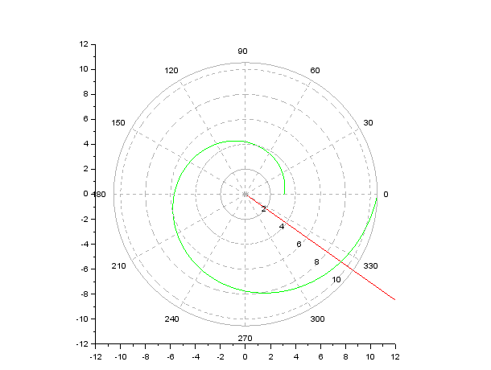

траектории для случая 1

## Результаты

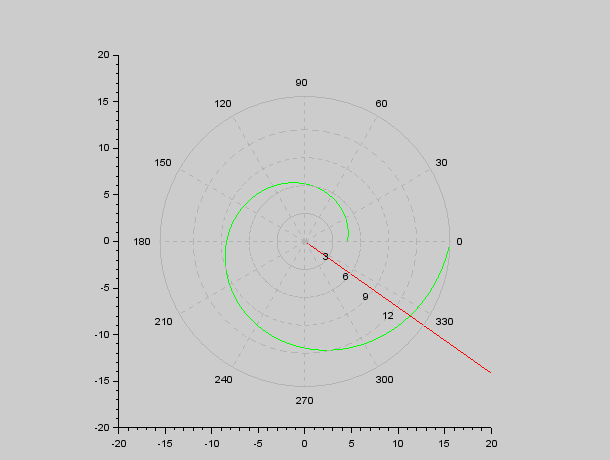

траектории для случая 2

# Выводы по проделанной работе

## Вывод

Рассмотрели задачу о погоне. Провели анализ и вывод дифференциальных уравнений. Смоделировали ситуацию.

Наблюдаем, что при погоне «по часовой стрелке» для достижения цели потребуется пройти значительно меньшее расстояние.